# Practical Machine Learning - Course Project

Lucas Moraes

# Load libraries

```r
library(caret)
library(randomForest)
library(xgboost)
library(dplyr)
library(VIM)
```

# Get the data

```r
data_dir = "./data"
training_url = "https://d396qusza40orc.cloudfront.net/predmachlearn/pml-training.csv"
test_url = "https://d396qusza40orc.cloudfront.net/predmachlearn/pml-testing.csv"
training_file = "pml-training.csv"
test_file = "pml-test.csv"
if (!file.exists(data_dir)) {
  dir.create(data_dir)
}
if (!file.exists(file.path(data_dir, training_file))) {
  download.file(training_url, destfile=file.path(data_dir, training_file))
}
if (!file.exists(file.path(data_dir, test_file))) {
  download.file(test_url, destfile=file.path(data_dir, test_file))
}
```

## Read the Data

Load the data into 2 different data frames

```r
train <- read.csv(file.path(data_dir, training_file), na.strings=c("NA","#DIV/0!", ""), stringsAsFactors = F)
test <- read.csv(file.path(data_dir, test_file), na.strings=c("NA","#DIV/0!", ""))
dim(train)
```

```
## [1] 19622   160
```

```r
dim(test)
```

```
## [1]  20 160
```

```r
head(train)
```

```
##   X user_name raw_timestamp_part_1 raw_timestamp_part_2   cvtd_timestamp
## 1 1  carlitos           1323084231               788290 05/12/2011 11:23
## 2 2  carlitos           1323084231               808298 05/12/2011 11:23
## 3 3  carlitos           1323084231               820366 05/12/2011 11:23
## 4 4  carlitos           1323084232               120339 05/12/2011 11:23
## 5 5  carlitos           1323084232               196328 05/12/2011 11:23
## 6 6  carlitos           1323084232               304277 05/12/2011 11:23
##   new_window num_window roll_belt pitch_belt yaw_belt total_accel_belt
## 1         no         11      1.41       8.07    -94.4                3
## 2         no         11      1.41       8.07    -94.4                3
## 3         no         11      1.42       8.07    -94.4                3
## 4         no         12      1.48       8.05    -94.4                3
## 5         no         12      1.48       8.07    -94.4                3
## 6         no         12      1.45       8.06    -94.4                3
##   kurtosis_roll_belt kurtosis_picth_belt kurtosis_yaw_belt skewness_roll_belt
```

[output cut: 251 more lines]

The training data set contains 19622 observations and 160 variables, while the testing data set contains 20 observations and 160 variables. The “classe” variable in the training set is the outcome to predict.

## Clean the data

Check if in the observations are present NA values or missing OBS that can raise errors/bias during the model training.

```r
sum(complete.cases(train))
```

```
## [1] 0
```

Too few observations to have a correct training.

### Eliminate the columns with NA/missing values

Let’s see colnames

```r
colnames(train)
```

```
##   [1] "X"                        "user_name"
##   [3] "raw_timestamp_part_1"     "raw_timestamp_part_2"
##   [5] "cvtd_timestamp"           "new_window"
##   [7] "num_window"               "roll_belt"
##   [9] "pitch_belt"               "yaw_belt"
##  [11] "total_accel_belt"         "kurtosis_roll_belt"
##  [13] "kurtosis_picth_belt"      "kurtosis_yaw_belt"
##  [15] "skewness_roll_belt"       "skewness_roll_belt.1"
##  [17] "skewness_yaw_belt"        "max_roll_belt"
##  [19] "max_picth_belt"           "max_yaw_belt"
##  [21] "min_roll_belt"            "min_pitch_belt"
##  [23] "min_yaw_belt"             "amplitude_roll_belt"
##  [25] "amplitude_pitch_belt"     "amplitude_yaw_belt"
##  [27] "var_total_accel_belt"     "avg_roll_belt"
##  [29] "stddev_roll_belt"         "var_roll_belt"
```

[output cut: 65 more lines]

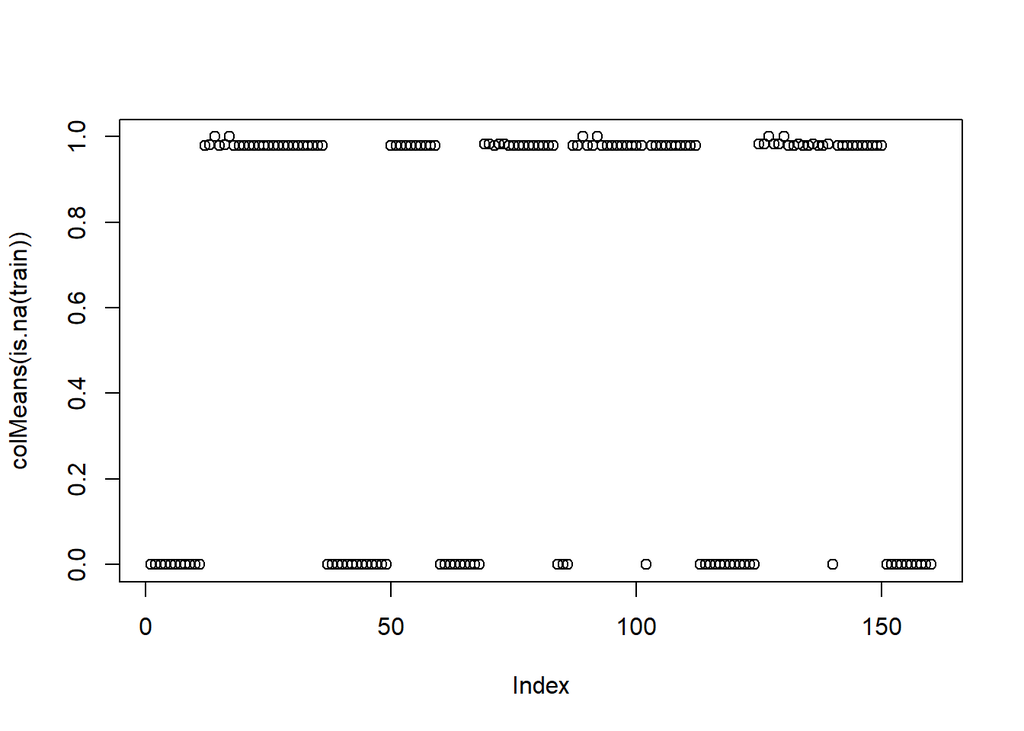

```r
plot(colMeans(is.na(train)))
```

There are columns with a lot of missing values.

We will retain only the columns without NA values

```r
trainClasse = train$classe
trainRaw = train[, sapply(train, is.numeric)]
testRaw = test[, sapply(test, is.numeric)]
```

Remove columns with NA values

```r
trainFilter <- trainRaw[, colSums(is.na(trainRaw)) == 0]
# Attach Classe variable
trainFilter$classe = trainClasse
testFilter <- testRaw[, colSums(is.na(testRaw)) == 0]
```

Dimension

```r
dim(trainFilter)
```

```
## [1] 19622    57
```

```r
dim(testFilter)
```

```
## [1] 20 57
```

Removing other unuseful columns like username, timestamp and ID

```r
unwanted = !grepl("X|timestamp", colnames(trainFilter))
cols = colnames(trainFilter)[unwanted]
trainFilter = trainFilter %>%
  select(cols)
```

```
## Note: Using an external vector in selections is ambiguous.
## i Use `all_of(cols)` instead of `cols` to silence this message.
## i See <https://tidyselect.r-lib.org/reference/faq-external-vector.html>.
```

```r
unwanted = !grepl("X|timestamp", colnames(testFilter))
cols = colnames(testFilter)[unwanted]
testFilter = testFilter %>%
  select(cols)
```

Get dimension of the filtered dataset

```r
dim(trainFilter)
```

```
## [1] 19622    54
```

```r
dim(testFilter)
```

```
## [1] 20 54
```

## Slice the data

```r
set.seed(01312021) # Today's date
inTrain <- createDataPartition(trainFilter$classe, p=0.70, list=F)
trainData <- trainFilter[inTrain, ]
validationData <- trainFilter[-inTrain, ]
dim(trainData)
```

```
## [1] 13737    54
```

# Data modeling

We will fit a model using **Random Forest** and **XGBoost** (very popular in challange like kaggle.com) for several reasons:

1. With tree-based models, **you can safely ignore** predictors correlation issues
2. Zero- and Near Zero-Variance Predictors **does not** imply on tree-based models
3. As each feature is processed separately, and the possible splits of the data don’t depend on scaling, no preprocessing like normalization or standardization of features is needed for decision tree algorithms.

## Random forest

### Model

```r
#controlRf <- trainControl(method="cv", 5, allowParallel = TRUE)
modelRf <- train(classe ~ ., data=trainData, ntree = 100, method="rf", trControl = trainControl(method = "cv", number = 5,allowParallel = TRUE))
modelRf
```

```
## Random Forest
##
## 13737 samples
##    53 predictor
##     5 classes: 'A', 'B', 'C', 'D', 'E'
##
## No pre-processing
## Resampling: Cross-Validated (5 fold)
## Summary of sample sizes: 10991, 10988, 10989, 10990, 10990
## Resampling results across tuning parameters:
##
##   mtry  Accuracy   Kappa
##    2    0.9941040  0.9925411
##   27    0.9966518  0.9957648
##   53    0.9948317  0.9934623
##
## Accuracy was used to select the optimal model using the largest value.
## The final value used for the model was mtry = 27.
```

### Performance of the model on the validation data set

```r
# Change the factors to avoid Error: data and reference should be factors with the same levels.
predict_rf <- predict(modelRf, validationData)
confMatRF <- confusionMatrix(as.factor(validationData$classe), predict_rf)
confMatRF$table
```

```
##           Reference
## Prediction    A    B    C    D    E
##          A 1673    1    0    0    0
##          B    3 1132    4    0    0
##          C    0    0 1025    1    0
##          D    0    0    5  959    0
##          E    0    0    0    0 1082
```

Calculate accuracy with a Random Forest Model

```r
rfAccuracy = confMatRF$overall[[1]]
rfAccuracy
```

```
## [1] 0.9976211
```

Very accurate model to classify **classe** feature

## XGBoost

```r
controlXGB <- trainControl(method="cv", 5, allowParallel = TRUE)
modelXGB <- train(classe ~ ., data=trainData, method="xgbTree", trControl=controlXGB)
```

```r
modelXGB
```

```
## eXtreme Gradient Boosting
##
## 13737 samples
##    53 predictor
##     5 classes: 'A', 'B', 'C', 'D', 'E'
##
## No pre-processing
## Resampling: Cross-Validated (5 fold)
## Summary of sample sizes: 10989, 10990, 10988, 10991, 10990
## Resampling results across tuning parameters:
##
##   eta  max_depth  colsample_bytree  subsample  nrounds  Accuracy   Kappa
##   0.3  1          0.6               0.50        50      0.8102224  0.7594850
##   0.3  1          0.6               0.50       100      0.8847643  0.8541654
##   0.3  1          0.6               0.50       150      0.9166493  0.8945272
##   0.3  1          0.6               0.75        50      0.8144445  0.7648432
##   0.3  1          0.6               0.75       100      0.8833080  0.8523060
##   0.3  1          0.6               0.75       150      0.9150484  0.8924985
##   0.3  1          0.6               1.00        50      0.8132061  0.7631551
##   0.3  1          0.6               1.00       100      0.8827990  0.8517007
##   0.3  1          0.6               1.00       150      0.9132282  0.8902099
##   0.3  1          0.8               0.50        50      0.8138609  0.7641001
##   0.3  1          0.8               0.50       100      0.8873123  0.8573665
##   0.3  1          0.8               0.50       150      0.9167959  0.8947210
##   0.3  1          0.8               0.75        50      0.8118226  0.7614805
##   0.3  1          0.8               0.75       100      0.8835267  0.8525963
##   0.3  1          0.8               0.75       150      0.9150482  0.8925001
##   0.3  1          0.8               1.00        50      0.8124783  0.7622480
##   0.3  1          0.8               1.00       100      0.8831630  0.8521553
##   0.3  1          0.8               1.00       150      0.9145384  0.8918688
##   0.3  2          0.6               0.50        50      0.9529016  0.9404128
##   0.3  2          0.6               0.50       100      0.9863145  0.9826875
##   0.3  2          0.6               0.50       150      0.9942496  0.9927260
##   0.3  2          0.6               0.75        50      0.9500625  0.9368238
##   0.3  2          0.6               0.75       100      0.9875520  0.9842537
##   0.3  2          0.6               0.75       150      0.9952688  0.9940155
##   0.3  2          0.6               1.00        50      0.9541387  0.9419835
##   0.3  2          0.6               1.00       100      0.9885711  0.9855435
##   0.3  2          0.6               1.00       150      0.9960694  0.9950282
##   0.3  2          0.8               0.50        50      0.9552312  0.9433713
```

[output cut: 73 more lines]

```
##   0.4  3          0.8               0.50       150      0.9988355  0.9985270
##   0.4  3          0.8               0.75        50      0.9954871  0.9942916
##   0.4  3          0.8               0.75       100      0.9989811  0.9987112
##   0.4  3          0.8               0.75       150      0.9990537  0.9988031
##   0.4  3          0.8               1.00        50      0.9959965  0.9949361
##   0.4  3          0.8               1.00       100      0.9990538  0.9988031
##   0.4  3          0.8               1.00       150      0.9991265  0.9988952
##
## Tuning parameter 'gamma' was held constant at a value of 0
## Tuning
##  parameter 'min_child_weight' was held constant at a value of 1
## Accuracy was used to select the optimal model using the largest value.
## The final values used for the model were nrounds = 150, max_depth = 3, eta
##  = 0.3, gamma = 0, colsample_bytree = 0.6, min_child_weight = 1 and subsample
##  = 1.
```

### Performance of the model on the validation data set

```r
predict_XGB <- predict(modelXGB, validationData)
confMatXGB <- confusionMatrix(as.factor(validationData$classe), predict_XGB)
confMatXGB$table
```

```
##           Reference
## Prediction    A    B    C    D    E
##          A 1674    0    0    0    0
##          B    1 1138    0    0    0
##          C    0    0 1026    0    0
##          D    0    0    0  964    0
##          E    0    0    0    2 1080
```

Calculate accuracy with a XGBoost Model

```r
xgbAccuracy = confMatXGB$overall[[1]]
xgbAccuracy
```

```
## [1] 0.9994902
```

With XGB we reach a better accuracy on validation data.

# Compare models

```r
# collect resamples
model_results <- resamples(list(RF=modelRf, XGB=modelXGB))
# summarize the distributions
summary(model_results)
```

```
##
## Call:
## summary.resamples(object = model_results)
##
## Models: RF, XGB
## Number of resamples: 5
##
## Accuracy
##          Min.   1st Qu.    Median      Mean   3rd Qu.      Max. NA's
## RF  0.9952693 0.9952710 0.9963597 0.9966518 0.9978158 0.9985433    0
## XGB 0.9989083 0.9992725 0.9996358 0.9994177 0.9996360 0.9996360    0
##
## Kappa
##          Min.   1st Qu.    Median      Mean   3rd Qu.      Max. NA's
## RF  0.9940160 0.9940178 0.9953955 0.9957648 0.9972374 0.9981574    0
## XGB 0.9986192 0.9990797 0.9995394 0.9992635 0.9995396 0.9995396    0
```

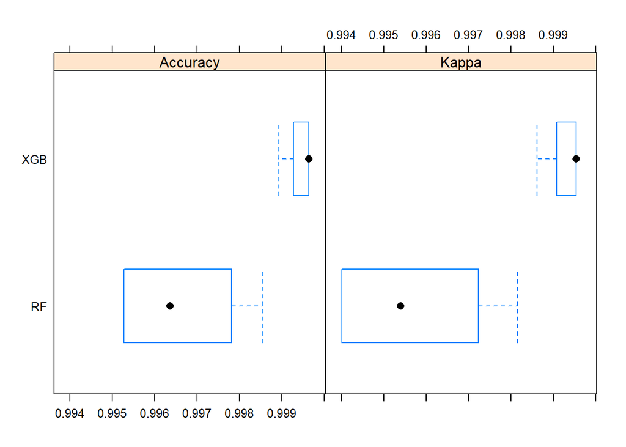

```r
# boxplots of results
bwplot(model_results)
```

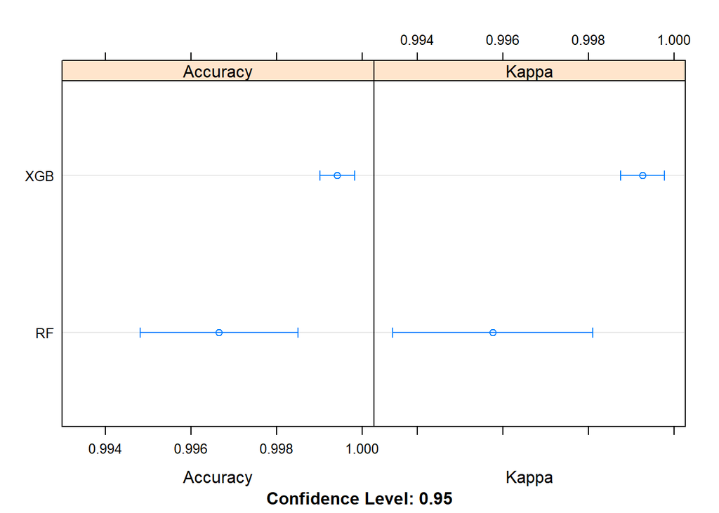

```r
# dot plots of results
dotplot(model_results)
```

# Predict Test data with RF and XGB

```r
resultRf <- predict(modelRf, testFilter[, -length(names(testFilter))])
resultXGB <- predict(modelXGB, testFilter[, -length(names(testFilter))])
resultRf
```

```
##  [1] B A B A A E D B A A B C B A E E A B B B
## Levels: A B C D E
```

```r
resultXGB
```

```
##  [1] B A B A A E D B A A B C B A E E A B B B
## Levels: A B C D E
```

```r
confusionMatrix(resultRf, resultXGB)$table
```

```
##           Reference
## Prediction A B C D E
##          A 7 0 0 0 0
##          B 0 8 0 0 0
##          C 0 0 1 0 0
##          D 0 0 0 1 0
##          E 0 0 0 0 3
```

Finally the model predict the TEST data in the same way, but we noticed that XGB works better with the training set